# Class 12

DATA1220-55, Fall 2024

Sarah E. Grabinski

2024-09-25

## Probability Review

- (General) Addition Rule
- (General) Multiplication Rule
- Dependence vs Independence

## The General Addition Rule

The probability of event A *or* event B occurring is the sum of the probability that A occurs and the probability that B occurs minus the probability that A *and* B occurs.

$$\begin{aligned}
P(A \operatorname{or} B) &= P(A) + P(B) - P(A \operatorname{and} B) \\
&= P(A) + P(B) - P(A \cup B) \\
&= P(A \cap B)
\end{aligned}$$

## The Addition Rule for Disjoint Events

When events A and B are *disjoint*, the probability of event A *or* event B occurring is just the sum of the probability that A occurs and the probability that B occurs, because the probability that event A *and* event B occurs is 0.

$$\begin{aligned}
P(A \operatorname{or} B) &= P(A) + P(B) - P(A \operatorname{and} B) \\
&= P(A) + P(B) \\
&= P(A \cap B)
\end{aligned}$$

## The General Multiplication Rule

The probability of event A *and* event B occurring is the product of the probability that A occurs and the *conditional probability* that B occurs given that A has already occurred.

$$\begin{aligned}
P(A \operatorname{and} B) &= P(A) \times P(B \operatorname{given} A) \\
&= P(A) \times P(B | A) \\
&= P(A \cup B)
\end{aligned}$$

## Independent Processes

- If random process B is *independent* of random process A, then the probability of random process B does NOT vary based on the outcome of random process A
- *i.e. knowing the outcome of A does NOT provide additional information about the probability of B*
- Example: When listening to a playlist using a “true shuffle”, the probability that the next song will be by a particular artist *does not* change based on whether or not the last song played was also by that artist.

## Multiplication Rule for Independent Processes

The probability of event A *and* event B occurring is the product of the probability that A occurs and the probability that B occurs, because the probability of B does not change based on the outcome of A.

$$\begin{aligned}
P(A \operatorname{and} B) &= P(A) \times P(B \operatorname{given} A) \\
&= P(A) \times P(B | A) \\
&= P(A) \times P(B) \\
&= P(A \cup B)
\end{aligned}$$

## How do you know if two random processes are independent?

- Compare the conditional probabilities of B given the different possible outcomes of A. If $P(B|A)\approx P(B)$ for all values of A, then the two random processes are likely independent.
- Calculate the probability that event A and B occur under both an independence model ($P(A \operatorname{and} B)=P(A)\times P(B)$) and a dependence model ($P(A \operatorname{and} B) = P(A) \times P(B|A)$.
  - If $P(A)\times P(B) \approx P(A) \times P(B|A)$, then A and B are likely *independent processes*.
  - If $P(A)\times P(B) \neq P(A) \times P(B|A)$, then A and B are likely *dependent* processes.

## Practice: Swing Voters

- Pew Research survey asked 2,373 randomly sampled registered voters about their…
  - Political affilitation (Democrat, Republican, Independent)
  - Whether they consider themselves a swing voter (Yes, No)
- 35% responded Independent, 23% identified as swing voters, and 11% identified as both

## Pratice: Swing Voters

- Are these events disjoint or non-disjoint?
- What does the sample space look like?
- What do the contingency tables look like?
- What % of voters identify as an Independent *or* a swing voter?
- What % of voters identify as *neither* an Independent *nor* a swing voter?
- Are identifying as an Independent and identifying as a swing voter dependent or independent processes?

## Pratice: Poverty and Language

The American Community Survey (ACS) provides public data each year to give communities demographic information to plan investments and services. The 2010 ACS estimates that…

- 14.6% of Americans live below the poverty line
- 20.7% of Americans speak a language other than English at home
- 31.1% of Americans live below the poverty line *or* speak a language other than English at home

## Pratice: Poverty and Language

- Are these events disjoint or non-disjoint?
- What does the sample space look like?
- What do the contingency tables look like?
- What % of Americans live below the poverty line *and* speak a language other than English at home?
- What % of Americans live below the poverty line *and* speak only English at home?
- Are living below the poverty line and speaking a language other than English at home dependent or independent?

## Chapter 4 - Distributions

- We will *only* be covering Chapter 4.1 on the normal distribution in your textbook
- If you have an interest in math or statistics, you may want to read the rest of Chapter 4
  - 4.2 - Geometric distribution
  - 4.3 - Binomial distribution
  - 4.4 - Negative binomial distribution
  - 4.5 - Poisson distribution

## Chapter 4 Objectives

- Identify and describe the standard normal and normal distributions
- Standardize normal distributions and calculate Z-scores
- Calculate percentiles and exact probabilities
- Apply the 68-95-99.7 Rule
- Read a QQ-Plot (not in book)

## The Normal Distribution

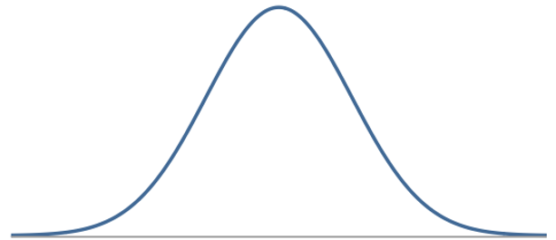

## Notation

- $\mu$ (Greek letter mu) represents the mean
- $\sigma$ (Greek letter sigma) represents the standard deviation of the mean
- $N(\mu, \sigma)$ stands for a normal distribution with mean $\mu$ and standard deviation $\sigma$

## Histograms and Density Curves

[figure not shown]

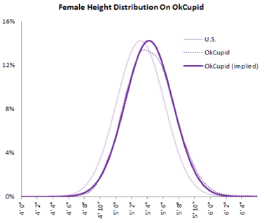

Dashed line is self-reported heights by females on OkCupid. Dark purple line is the normal distribution with the same mean and standard deviation. Light purple line is the US average.

## The shape of a normal distribution varies by location (mean) and scale (standard deviation)

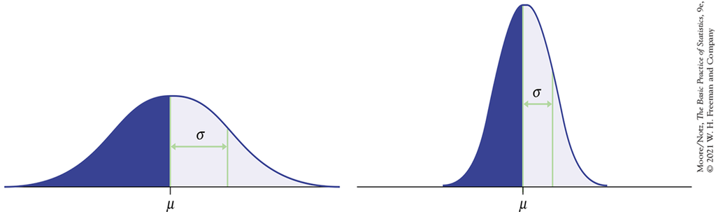

Changing the mean shifts the “center” of the distribution. Changing the standard deviation alters the “width” of the distribution (i.e. variability).

## Standardizing Normal Distributions with Z-Scores

- A *Z-score* is the number of standard deviations a value falls above (when positive) or below (when negative) the mean of the data
- Z-scores standardize a normal distribution by…
  - Centering the data at 0 by subtracting the mean from each score
  - Scaling the units of the data to 1 by dividing the centered data by the standard deviation

## Calculating the Z-Score

$$\begin{aligned}
Z&=\frac{\operatorname{observed value}-\operatorname{mean}}{\operatorname{standard deviation}} \\
&= \frac{x-\mu}{\sigma}
\end{aligned}$$

## Example: Test Scores

- SAT scores are normally distributed with $\mu=1500$ and $\sigma=300$ ($N(\mu=1500, \sigma = 300)$)
- ACT scores are normally distributed with $\mu=21$ and $\sigma=5$ ($N(21, 5)$)

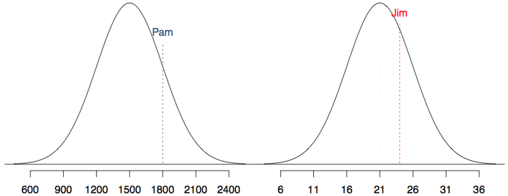

How do we compare normal distributions with different locations and scales?

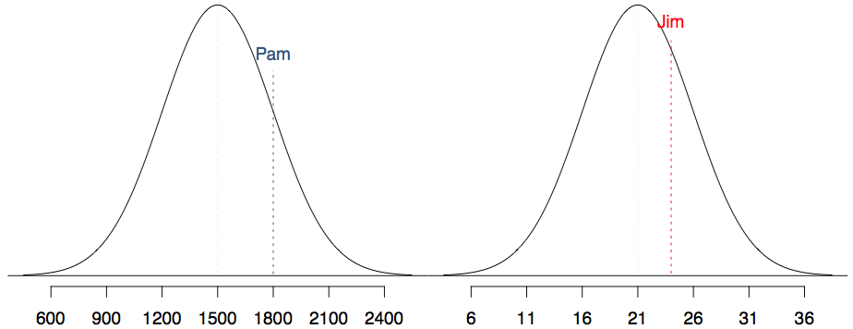

## The Standard Normal Distribution

- The *standard normal distribution* is a normal distribution with $\mu=0$ and $\sigma=1$ (written $N(\mu=0, \sigma=1)$)
- Units of the standard normal distribution are standard deviations (Z-scores) (i.e. 1 unit = 1 SD)
- Observations that are 2+ standard deviations from the mean are considered unusual

## The 68-95-99.7 Rule

When data is (nearly) normally distributed…

DATA1220-55 Fall 2024, Class 12 | Updated: 2024-09-25 | [Canvas](https://canvas.jcu.edu/courses/36290) | [Campuswire](https://campuswire.com/c/G6427C531/feed)